# An Exploratory Data Analysis on Airline Customer Satisfaction

Parv Bhargava, Jehan Bugli, Venkata Madisetty, and Namratha Prakash

2023-10-20

Head

| X | id | Gender | Customer.Type | Age | Type.of.Travel | Class | Flight.Distance | Inflight.wifi.service | Departure.Arrival.time.convenient | Ease.of.Online.booking | Gate.location | Food.and.drink | Online.boarding | Seat.comfort | Inflight.entertainment | On.board.service | Leg.room.service | Baggage.handling | Checkin.service | Inflight.service | Cleanliness | Departure.Delay.in.Minutes | Arrival.Delay.in.Minutes | satisfaction |
| --- | --- | --- | --- | --- | --- | --- | --- | --- | --- | --- | --- | --- | --- | --- | --- | --- | --- | --- | --- | --- | --- | --- | --- | --- |
| 0 | 70172 | Male | Loyal Customer | 13 | Personal Travel | Eco Plus | 460 | 3 | 4 | 3 | 1 | 5 | 3 | 5 | 5 | 4 | 3 | 4 | 4 | 5 | 5 | 25 | 18 | neutral or dissatisfied |
| 1 | 5047 | Male | disloyal Customer | 25 | Business travel | Business | 235 | 3 | 2 | 3 | 3 | 1 | 3 | 1 | 1 | 1 | 5 | 3 | 1 | 4 | 1 | 1 | 6 | neutral or dissatisfied |
| 2 | 110028 | Female | Loyal Customer | 26 | Business travel | Business | 1142 | 2 | 2 | 2 | 2 | 5 | 5 | 5 | 5 | 4 | 3 | 4 | 4 | 4 | 5 | 0 | 0 | satisfied |
| 3 | 24026 | Female | Loyal Customer | 25 | Business travel | Business | 562 | 2 | 5 | 5 | 5 | 2 | 2 | 2 | 2 | 2 | 5 | 3 | 1 | 4 | 2 | 11 | 9 | neutral or dissatisfied |
| 4 | 119299 | Male | Loyal Customer | 61 | Business travel | Business | 214 | 3 | 3 | 3 | 3 | 4 | 5 | 5 | 3 | 3 | 4 | 4 | 3 | 3 | 3 | 0 | 0 | satisfied |

# Prior Code (kept for easier re-integration)

#### **Duplicate values**

Missing Values — Initial

| X | id | Gender | Customer.Type | Age | Type.of.Travel | Class | Flight.Distance | Inflight.wifi.service | Departure.Arrival.time.convenient | Ease.of.Online.booking | Gate.location | Food.and.drink | Online.boarding | Seat.comfort | Inflight.entertainment | On.board.service | Leg.room.service | Baggage.handling | Checkin.service | Inflight.service | Cleanliness | Departure.Delay.in.Minutes | Arrival.Delay.in.Minutes | satisfaction |
| --- | --- | --- | --- | --- | --- | --- | --- | --- | --- | --- | --- | --- | --- | --- | --- | --- | --- | --- | --- | --- | --- | --- | --- | --- |
| 0 | 0 | 0 | 0 | 0 | 0 | 0 | 0 | 0 | 0 | 0 | 0 | 0 | 0 | 0 | 0 | 0 | 0 | 0 | 0 | 0 | 0 | 0 | 310 | 0 |

```r
data
```

[output not shown]

[output cut: 39118 more lines]

```
##  Pre_Flight_and_WiFi_Ratings In_Flight_and_Baggage_Ratings
##  Min.   :1.00                Min.   :1.11
##  1st Qu.:2.40                1st Qu.:2.78
##  Median :3.00                Median :3.44
##  Mean   :3.04                Mean   :3.41
##  3rd Qu.:3.80                3rd Qu.:4.00
##  Max.   :5.00                Max.   :5.00
```

# Probability and standard OLS estimates

Before engaging in further analysis, we first identified that satisfaction—as a categorical/binary variable—runs into a fundamental interpretation issue under a standard linear model, where **the standard linear model is not bounded between 0 and 1 in the same manner as our satisfaction variable**. Under certain inputs, the linear model predicts unattainable values between satisfied or neutral/dissatisfied (encoded as 1 and 0 respectively), and key assumptions of linearity and homoskedasticity are violated.

Despite this restriction, linear probability models remain in widespread use, particularly among social scientists, making this a potentially fruitful avenue for a predictive model (Allison, 2015). This largely stems from ease of interpretation and generation; unlike logit (to be discussed later), this directly predicts changes in probability rather than odds ratios, is easier to run, and approximates logit for the 0.2-0.8 probability range in most cases (Allison, 2020). We generated a linear model and used a t-test with robust standard errors to account for violated homoskedasticity assumptions.

```
##
## Call:
## lm(formula = satisfaction ~ Gender + Customer.Type + Age + Type.of.Travel +
##     Class + Flight.Distance + Pre_Flight_and_WiFi_Ratings + In_Flight_and_Baggage_Ratings,
##     data = data)
##
## Residuals:
##    Min     1Q Median     3Q    Max
## -1.076 -0.223  0.005  0.198  1.426
##
## Coefficients:
##                                Estimate Std. Error t value
## (Intercept)                   -1.31e+00   6.57e-03 -198.79
## Gender                        -3.81e-04   2.14e-03   -0.18
## Customer.Type                  3.57e-01   3.40e-03  105.08
## Age                            1.87e-04   7.44e-05    2.51
## Type.of.Travel                 4.35e-01   3.08e-03  140.99
## Class                          1.25e-01   2.96e-03   42.30
## Flight.Distance                5.88e-06   1.24e-06    4.74
## Pre_Flight_and_WiFi_Ratings    9.07e-02   1.18e-03   76.63
## In_Flight_and_Baggage_Ratings  2.29e-01   1.46e-03  157.09
##                               Pr(>|t|)
## (Intercept)                    < 2e-16 ***
## Gender                           0.858
## Customer.Type                  < 2e-16 ***
## Age                              0.012 *
## Type.of.Travel                 < 2e-16 ***
## Class                          < 2e-16 ***
## Flight.Distance                2.1e-06 ***
## Pre_Flight_and_WiFi_Ratings    < 2e-16 ***
## In_Flight_and_Baggage_Ratings  < 2e-16 ***
## ---
## Signif. codes:
## 0 '***' 0.001 '**' 0.01 '*' 0.05 '.' 0.1 ' ' 1
##
## Residual standard error: 0.33 on 95695 degrees of freedom
## Multiple R-squared:  0.554,  Adjusted R-squared:  0.554
## F-statistic: 1.48e+04 on 8 and 95695 DF,  p-value: <2e-16
```

```
##
## t test of coefficients:
##
##                                Estimate Std. Error t value
## (Intercept)                   -1.31e+00   5.69e-03 -229.60
## Gender                        -3.81e-04   2.14e-03   -0.18
## Customer.Type                  3.57e-01   3.89e-03   91.72
## Age                            1.87e-04   7.60e-05    2.46
## Type.of.Travel                 4.35e-01   3.40e-03  127.92
## Class                          1.25e-01   3.36e-03   37.28
## Flight.Distance                5.88e-06   1.22e-06    4.81
## Pre_Flight_and_WiFi_Ratings    9.07e-02   1.26e-03   72.12
## In_Flight_and_Baggage_Ratings  2.29e-01   1.52e-03  150.13
##                               Pr(>|t|)
## (Intercept)                    < 2e-16 ***
## Gender                           0.859
## Customer.Type                  < 2e-16 ***
## Age                              0.014 *
## Type.of.Travel                 < 2e-16 ***
## Class                          < 2e-16 ***
## Flight.Distance                1.5e-06 ***
## Pre_Flight_and_WiFi_Ratings    < 2e-16 ***
## In_Flight_and_Baggage_Ratings  < 2e-16 ***
## ---
## Signif. codes:
## 0 '***' 0.001 '**' 0.01 '*' 0.05 '.' 0.1 ' ' 1
```

```
##
## Call:
## lm(formula = satisfaction ~ Customer.Type + Type.of.Travel +
##     Class + Flight.Distance + Pre_Flight_and_WiFi_Ratings + In_Flight_and_Baggage_Ratings,
##     data = data)
##
## Residuals:
##    Min     1Q Median     3Q    Max
## -1.076 -0.222  0.005  0.198  1.425
##
## Coefficients:
##                                Estimate Std. Error t value
## (Intercept)                   -1.30e+00   6.22e-03 -209.08
## Customer.Type                  3.59e-01   3.28e-03  109.41
## Type.of.Travel                 4.36e-01   3.07e-03  141.88
## Class                          1.25e-01   2.95e-03   42.45
## Flight.Distance                5.77e-06   1.24e-06    4.66
## Pre_Flight_and_WiFi_Ratings    9.07e-02   1.18e-03   76.70
## In_Flight_and_Baggage_Ratings  2.29e-01   1.46e-03  157.15
##                               Pr(>|t|)
## (Intercept)                    < 2e-16 ***
## Customer.Type                  < 2e-16 ***
## Type.of.Travel                 < 2e-16 ***
## Class                          < 2e-16 ***
## Flight.Distance                3.2e-06 ***
## Pre_Flight_and_WiFi_Ratings    < 2e-16 ***
## In_Flight_and_Baggage_Ratings  < 2e-16 ***
## ---
## Signif. codes:
## 0 '***' 0.001 '**' 0.01 '*' 0.05 '.' 0.1 ' ' 1
##
## Residual standard error: 0.33 on 95697 degrees of freedom
## Multiple R-squared:  0.554,  Adjusted R-squared:  0.554
## F-statistic: 1.98e+04 on 6 and 95697 DF,  p-value: <2e-16
```

```r
# Check for missing values
missing_data <- data_test %>%
  summarise_all(~ sum(is.na(.)))

# Check for duplicated rows
duplicate_rows <- data_test %>%
  summarise(n_duplicates = sum(duplicated(.)))

# Get unnecessary columns
drop <- c("X","id")
# Drop column names specified in vector
data_test <- data_test[,!(names(data_test) %in% drop)]

# Select ratings columns
selected_columns <- 7:20

# Check if any ratings include zeros (representing N/A)
has_zeros <- apply(data_test[selected_columns], 1, function(row) any(row == 0))

# Remove rows with zeros in the selected columns
data_test <- data_test[!has_zeros, ]


# Remove NA values which we acquired previously
data_test$Arrival.Delay.in.Minutes[is.na(data_test$Arrival.Delay.in.Minutes)] <- median(data_test$Arrival.Delay.in.Minutes, na.rm = TRUE)
missing_data <- data_test %>%
  summarise_all(~ sum(is.na(.)))

# Repeat encoding steps

data_test$satisfaction <- ifelse(data_test$satisfaction == "satisfied", 1, 0)

data_test$Gender <- ifelse(data_test$Gender == "Male", 1, 0)

data_test$Customer.Type <- ifelse(data_test$Customer.Type == "Loyal Customer", 1, 0)

data_test$Type.of.Travel <- ifelse(data_test$Type.of.Travel == "Business travel", 1, 0)

data_test$Class <- ifelse(data_test$Class %in% c("Eco", "Eco Plus"), 0,
                     ifelse(data_test$Class == "Business", 1, NA))


# Repeat ratings aggregation steps

# Select columns for Group1
ratings_group1_test <- select(data_test, Inflight.wifi.service, Departure.Arrival.time.convenient, Ease.of.Online.booking, Gate.location, Online.boarding)

# Calculate the average for Group1
data_test$Pre_Flight_and_WiFi_Ratings <- rowMeans(ratings_group1_test, na.rm = TRUE)

# Select columns for Group2
ratings_group2_test <- select(data_test, Food.and.drink, Seat.comfort, Inflight.entertainment, On.board.service, Leg.room.service, Baggage.handling, Checkin.service, Inflight.service, Cleanliness)

# Calculate the average for Group2
data_test$In_Flight_and_Baggage_Ratings <- rowMeans(ratings_group2_test, na.rm = TRUE)

data_ratings_combined_test <- data_test[c("Pre_Flight_and_WiFi_Ratings","In_Flight_and_Baggage_Ratings")]
```

```r
data_test$predicted_probabilities_linear <- predict(linear_model_v2, newdata = data_test)

data_test$predicted_outcome_linear <- ifelse(data_test$predicted_probabilities_linear > 0.5, 1, 0)

confusion_matrix <- table(data_test$satisfaction, data_test$predicted_outcome_linear)

print(confusion_matrix)
```

```
##
##         0     1
##   0 11939  1651
##   1  1561  8712
```

```r
accuracy <- sum(diag(confusion_matrix)) / sum(confusion_matrix)
print(paste("Accuracy:", round(accuracy, 3)))
```

```
## [1] "Accuracy: 0.865"
```

However, it is not yet clear that a linear model would be the best predictor available. **Logistic regression**, which predicts the log odds of satisfaction. is the dominant approach for modeling binary variables (Allison, 2015). Logistic regression models utilize different assumptions relative to linear models, significantly altering the necessary EDA steps. Rather than a linear relationship between parameters and the dependent variable, logistic regression assumes a linear relationship between parameters and the log odds. Independence of errors and multicollinearity remain as assumptions for both linear and logistic models. Homoskedasticity and normally distributed residuals are both not required under logistic regression (“Assumptions of Logistic Regression”, n.d.).

Unlike a standard linear regression, which assumes that independent parameters have a linear relationship with the dependent variable, **logistic regression assumes that parameters have a linear relationship with the log odds** (“Assumptions of Logistic Regression”, n.d.).

Odds represent the number of favorable outcomes divided by the number of unfavorable outcomes. Put differently, if “p” represents the probability of favorable outcomes, Odds = **p/(1-p)**. Log odds take the natural log of the odds, which can be expressed as **ln(p/1-p))** (Agarwal, 2019). We used visual test to examine whether or not this assumption holds true for continuous variables. While it is not sensible to compute log odds for individual data points, we grouped continuous variables into discrete buckets—calculating the average log odds for each—to examine whether or not they might satisfy this assumption.

Only flight distance, as well as in-flight and baggage ratings, displayed roughly linear relationships with log odds of satisfaction in our testing. Age appeared to have a parabolic relationship, peaking in the middle, indicating some sort of aggressive transformation method may be necessary to reach a linear relationship. Meanwhile, log odds for both delay statistics quickly dispersed in both directions as they increase (likely in part due to the limited frequency of higher durations), making it difficult to conclude with certainty that a linear relationship exists. Pre-flight and wi-fi ratings appear to have a significantly looser connection relative to in-flight ratings with a potential dip in log odds for average ratings.

# Testing Linearity with log odds

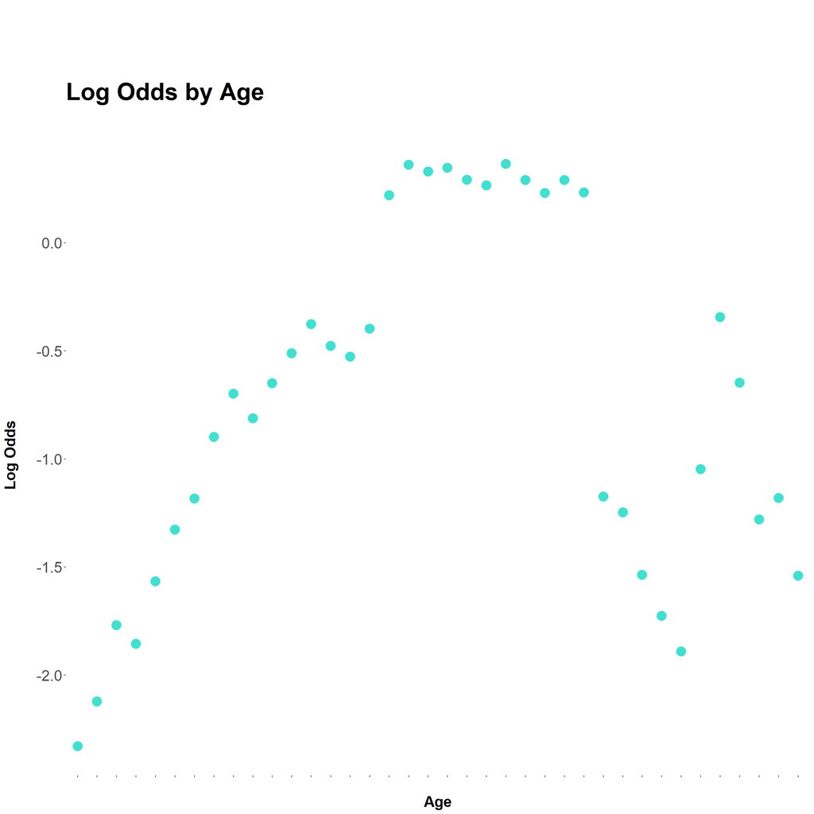

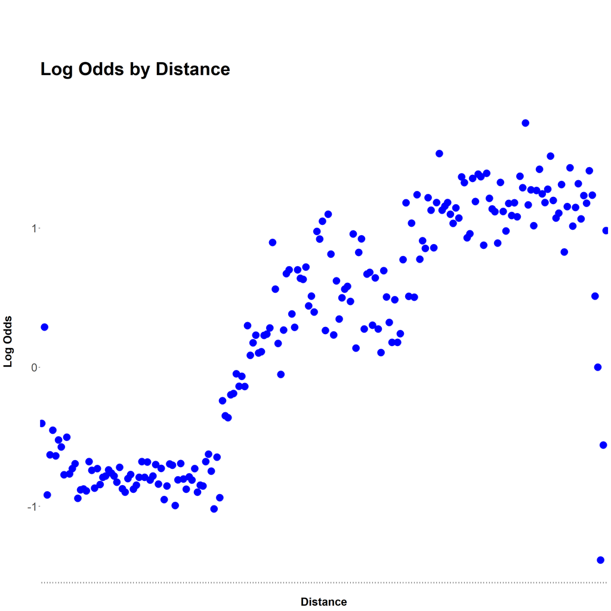

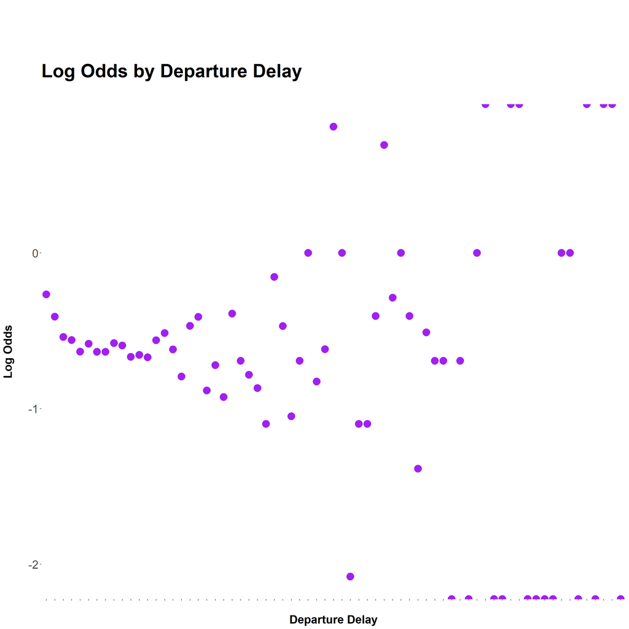

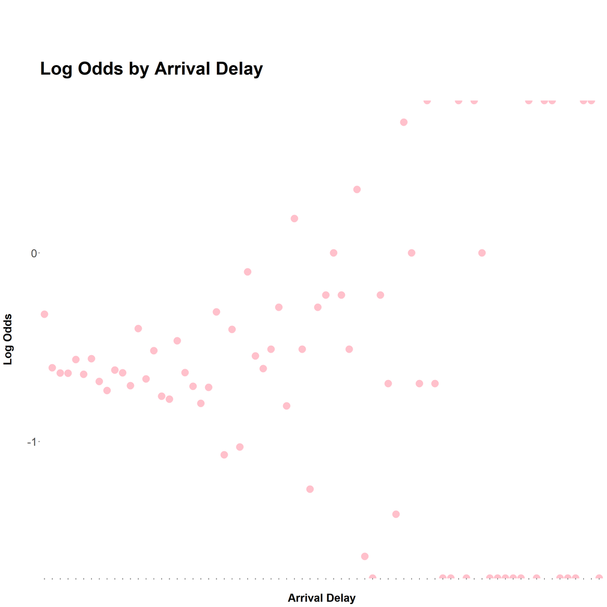

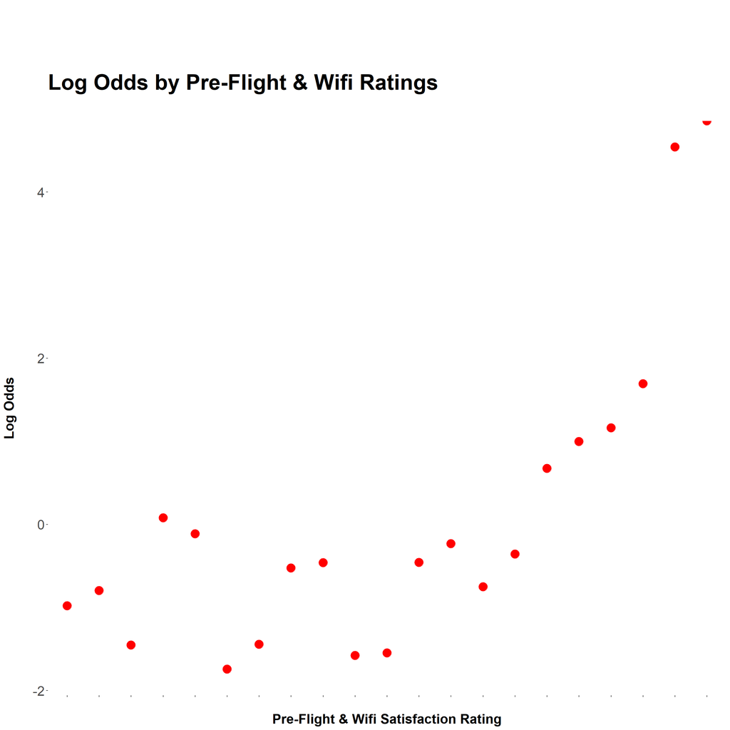

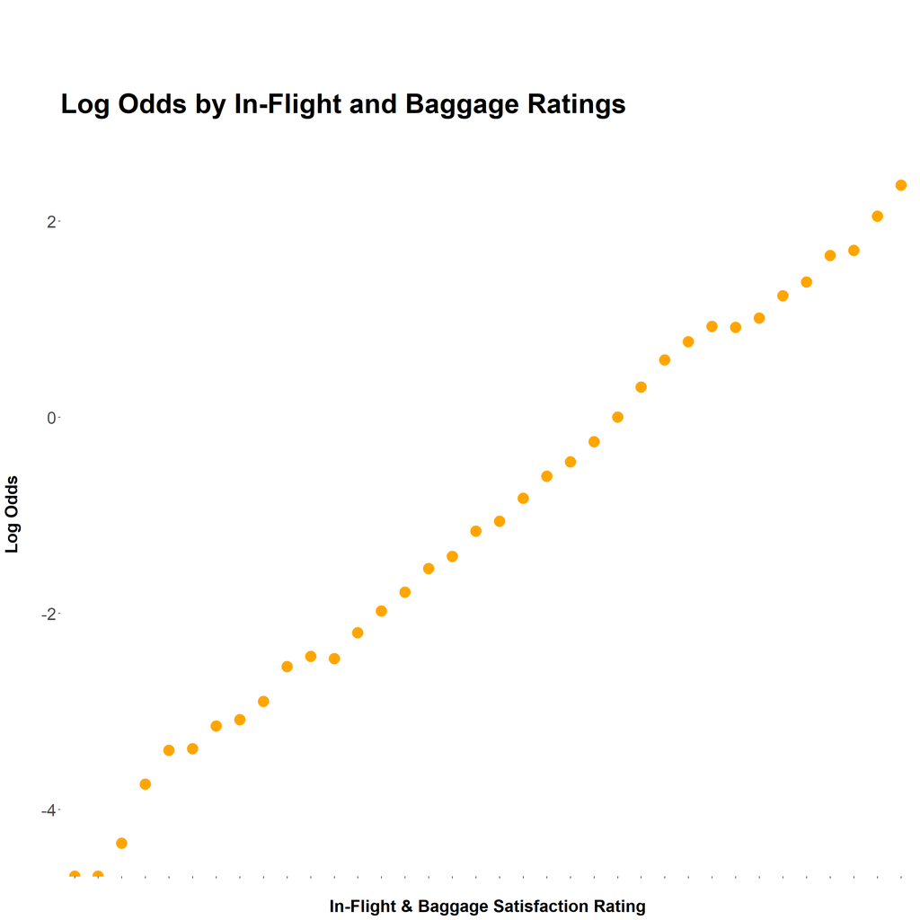

Following visual testing, we generated a logit model in order to examine potential differences relative to the prior linear model. Rather than starting with a pared-down variable list, we returned to an expanded variable list to see if there were any distinctions in what the models deemed statistically significant. This proved to be informative; alongside gender and age, flight distance also failed to reach the threshold for statistical significance.

```r
logit_model = glm(satisfaction ~ Gender + Customer.Type + Age + Type.of.Travel + Class + Flight.Distance + Pre_Flight_and_WiFi_Ratings + In_Flight_and_Baggage_Ratings, data = data, family = "binomial")

summary(logit_model)
```

```
##
## Call:
## glm(formula = satisfaction ~ Gender + Customer.Type + Age + Type.of.Travel +
##     Class + Flight.Distance + Pre_Flight_and_WiFi_Ratings + In_Flight_and_Baggage_Ratings,
##     family = "binomial", data = data)
##
## Coefficients:
##                                Estimate Std. Error z value
## (Intercept)                   -1.47e+01   9.86e-02 -148.85
## Gender                         5.79e-03   2.06e-02    0.28
## Customer.Type                  2.48e+00   3.19e-02   77.57
## Age                            7.10e-04   7.42e-04    0.96
## Type.of.Travel                 3.33e+00   3.24e-02  102.75
## Class                          8.32e-01   2.56e-02   32.53
## Flight.Distance                1.45e-05   1.18e-05    1.23
## Pre_Flight_and_WiFi_Ratings    8.30e-01   1.23e-02   67.58
## In_Flight_and_Baggage_Ratings  1.96e+00   1.67e-02  116.80
##                               Pr(>|z|)
## (Intercept)                     <2e-16 ***
## Gender                            0.78
## Customer.Type                   <2e-16 ***
## Age                               0.34
## Type.of.Travel                  <2e-16 ***
## Class                           <2e-16 ***
## Flight.Distance                   0.22
## Pre_Flight_and_WiFi_Ratings     <2e-16 ***
## In_Flight_and_Baggage_Ratings   <2e-16 ***
## ---
## Signif. codes:
## 0 '***' 0.001 '**' 0.01 '*' 0.05 '.' 0.1 ' ' 1
##
## (Dispersion parameter for binomial family taken to be 1)
##
##     Null deviance: 130562  on 95703  degrees of freedom
## Residual deviance:  61179  on 95695  degrees of freedom
## AIC: 61197
##
## Number of Fisher Scoring iterations: 6
```

In order to compare this with the linear model, we generated another confusion matrix based on the testing data. In a similar fashion to the linear model, we created a “v2” model removing statistically insignificant inputs. The accuracy results were better than those of the linear model, but only slightly; it isn’t clear whether this marginal improvement would hold true given further testing with different survey data. The calculated McFadden pseudo-R^2 falls above 0.5.

```r
logit_model_v2 = glm(satisfaction ~ Customer.Type + Type.of.Travel + Class + Pre_Flight_and_WiFi_Ratings + In_Flight_and_Baggage_Ratings, data = data, family = "binomial")

summary(logit_model_v2)
```

```
##
## Call:
## glm(formula = satisfaction ~ Customer.Type + Type.of.Travel +
##     Class + Pre_Flight_and_WiFi_Ratings + In_Flight_and_Baggage_Ratings,
##     family = "binomial", data = data)
##
## Coefficients:
##                               Estimate Std. Error z value
## (Intercept)                   -14.6554     0.0965  -151.9
## Customer.Type                   2.4940     0.0298    83.7
## Type.of.Travel                  3.3316     0.0321   103.8
## Class                           0.8450     0.0236    35.9
## Pre_Flight_and_WiFi_Ratings     0.8302     0.0123    67.6
## In_Flight_and_Baggage_Ratings   1.9558     0.0167   116.9
##                               Pr(>|z|)
## (Intercept)                     <2e-16 ***
## Customer.Type                   <2e-16 ***
## Type.of.Travel                  <2e-16 ***
## Class                           <2e-16 ***
## Pre_Flight_and_WiFi_Ratings     <2e-16 ***
## In_Flight_and_Baggage_Ratings   <2e-16 ***
## ---
## Signif. codes:
## 0 '***' 0.001 '**' 0.01 '*' 0.05 '.' 0.1 ' ' 1
##
## (Dispersion parameter for binomial family taken to be 1)
##
##     Null deviance: 130562  on 95703  degrees of freedom
## Residual deviance:  61181  on 95698  degrees of freedom
## AIC: 61193
##
## Number of Fisher Scoring iterations: 6
```

```r
data_test$predicted_probabilities_logit <- predict(logit_model_v2, newdata = data_test)

data_test$predicted_outcome_logit <- ifelse(data_test$predicted_probabilities_logit > 0.5, 1, 0)

confusion_matrix <- table(data_test$satisfaction, data_test$predicted_outcome_logit)

print(confusion_matrix)
```

```
##
##         0     1
##   0 12635   955
##   1  2189  8084
```

```r
accuracy <- sum(diag(confusion_matrix)) / sum(confusion_matrix)
print(paste("Accuracy:", round(accuracy, 3)))
```

```
## [1] "Accuracy: 0.868"
```

```r
logit_model_null <- glm(satisfaction ~ 1, data = data, family = "binomial")

mcFadden <- 1 - logLik(logit_model_v2)/logLik(logit_model_null)

print(paste("McFadden R^2:", round(mcFadden,3)))
```

```
## [1] "McFadden R^2: 0.531"
```

# Citations

Klein, TJ (2020). *Airline Passenger Satisfaction*. Kaggle. https://www.kaggle.com/datasets/teejmahal20/airline-passenger-satisfaction?select=train.csv

Lutz, A., & Lubin, G. (2012). *Airlines Have An Insanely Small Profit Margin*. Business Insider. https://www.businessinsider.com/airlines-have-a-small-profit-margin-2012-6

Hardee, H. (2023). *Frontier reports lacklustre Q3 results as it struggles in ‘over-saturated’ core markets*. FlightGlobal. https://www.flightglobal.com/strategy/frontier-reports-lacklustre-q3-results-as-it-struggles-in-over-saturated-core-markets/155561.article

*vif: Variance Inflation Factors*. (n.d.). R Package Documentation. https://rdrr.io/cran/car/man/vif.html

Allison, P. (2015, April 1). *What’s So Special About Logit?*. Statistical Horizons. https://statisticalhorizons.com/whats-so-special-about-logit/

Allison, P. (2020, April 24). *Better Predicted Probabilities from Linear Probability Models*. Statistical Horizons. https://statisticalhorizons.com/better-predicted-probabilities/

*Assumptions of Logistic Regression*. (n.d.). Statistics Solutions. https://www.statisticssolutions.com/free-resources/directory-of-statistical-analyses/assumptions-of-logistic-regression/

Agarwal, P. (2019, July 8). *WHAT and WHY of Log Odds*. Towards Data Science. https://towardsdatascience.com/https-towardsdatascience-com-what-and-why-of-log-odds-64ba988bf704